# Descriptive Statistic Project

### *4. CREAZIONE DI CLASSI PER VARIABILE QUANTITATIVA*

Per svolgere questa analisi ho usato come variabile ” sales ” (variabile quantitativa discreta).

- **Costruzione delle Classi**
  1. Ho calcolato l’ampiezza di ogni classe alla larghezza della variabile per determinare il range e i n seguito ho suddiviso il range in 10 intervalli di uguale ampiezza.
  2. Calcolo Frequenza assoluta, relativa e cumulata.
  3. Creazione del Grafico della distribuzione :

     Ho rappresentato le frequenze assolute con un grafico a barre, ruotando le etichette per migliorarne la leggibilità.

```r
library(dplyr)
library(knitr)

#Choosen Variable
var<- data$sales
#Classe Number (es. 10) and width
n_classi<-10
ampiezza <- ceiling((max(var) - min(var)) / n_classi)

#Create intervals
breaks<- seq(from = floor(min(var)),
             to = ceiling(max(var)+ampiezza),
             by= ampiezza
             )
#Classes Labels
etichette<- paste(head(breaks,-1), breaks[-1], sep = " - ")
#frequency Table
freq_table<- data.frame(
  class= cut(var, breaks = breaks, labels = etichette, right = FALSE),
  stringsAsFactors = FALSE
) %>%
  group_by(class) %>%
  summarise(
    Absolute_frequency = n(),
    .groups = 'drop'
  ) %>%
  mutate(
    Relative_frequency = Absolute_frequency / sum(Absolute_frequency),
    Cumulative_frequency = cumsum(Relative_frequency)
  ) %>%
  mutate(across(c(Relative_frequency, Cumulative_frequency), ~ round(.x, 2)))
#Tabular output
kable(freq_table, caption= "Frequency distribution for the variable sales")
```

Frequency distribution for the variable sales

| class | Absolute_frequency | Relative_frequency | Cumulative_frequency |
| --- | --- | --- | --- |
| 79 - 114 | 40 | 0.17 | 0.17 |
| 114 - 149 | 46 | 0.19 | 0.36 |
| 149 - 184 | 45 | 0.19 | 0.55 |
| 184 - 219 | 32 | 0.13 | 0.68 |
| 219 - 254 | 21 | 0.09 | 0.77 |
| 254 - 289 | 20 | 0.08 | 0.85 |
| 289 - 324 | 18 | 0.07 | 0.92 |
| 324 - 359 | 9 | 0.04 | 0.96 |
| 359 - 394 | 6 | 0.03 | 0.99 |
| 394 - 429 | 3 | 0.01 | 1.00 |

- **Grafico della Distribuzione**

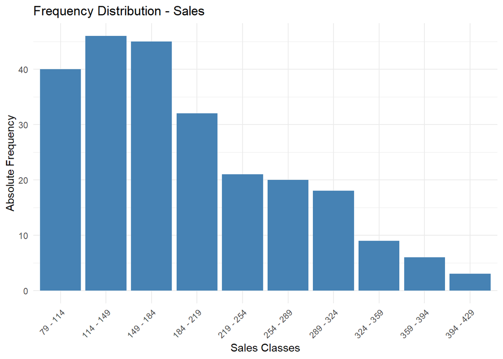

```r
library(ggplot2)
ggplot(freq_table, aes(x = class, y = Absolute_frequency)) +
  geom_bar(stat = "identity", fill = "steelblue") +
  labs(title = "Frequency Distribution - Sales",
       x = "Sales Classes",
       y = "Absolute Frequency") +
  theme_minimal() +
  theme(axis.text.x = element_text(angle = 45, hjust = 1))
```

- **Indice di Gini**

Formula :

- $G = 1-Σ fi^2$

  dove $fi$ sono le frequenze relative per classe.
  - G = 0 -> Distribuzione concentrata in poche classi (Bassa Eterogeneità)
  - G = 1 -> Distribuzione più uniforme (alta eterogeneità)

```r
#Absolute Frequency
ni<- freq_table$Absolute_frequency
#Relative Frequency
fi<- ni/length(data$sales)
fi2<- fi^2
j<- length(ni)

# Gini Index
gini <- 1 - sum(fi2)

# Normalized Gini Index
gini_norm <- gini / ((j - 1) / j)

# Tabular Output
gini_df <- data.frame(
  Indice_Gini = round(gini, 3),
  Indice_Gini_Normalizzato = round(gini_norm, 3)
)

kable(gini_df, caption = "Gini Index per variable 'sales'")
```

Gini Index per variable ‘sales’

| Indice_Gini | Indice_Gini_Normalizzato |
| --- | --- |
| 0.86 | 0.956 |

Dato che G = 0,86 , la distribuzione del sales è abbastanza eterogenea , quindi non tutte le vendite sono concentrate nella stessa classe.

### 5. CALCOLO DELLE PROBABILITA’

**Richiesta** : *“Qual è la probabilità che, presa una riga a caso di questo dataset, essa riporti la città “Beaumont”? E la probabilità che riporti il mese di Luglio? E la probabilità che riporti il mese di dicembre 2012?“*

Per risolvere tutte e 3 le richieste utilizzo il metodo di calcolo della **Probabilità Classica** :

$P(evento) = n° Casi favorevoli/ n° Tot casi Possibili$

dove :

- **casi favorevoli** = osservazioni che soddisfano la condizione dell’evento
- **casi possibili** = numero totale di osservazioni nel dataset

#### **1. Probabilità che la città sia “Beaumont”**

```r
library(knitr)
n_tot <- nrow(data)

#Probability city = Beaumont
n_beaumont <- sum(data$city == "Beaumont")
p_beaumont <- n_beaumont / n_tot
p_beaumont
```

```
## [1] 0.25
```

- P (città = ” Beaumont ” ) = 25%

#### **2. Probabilità che il mese sia “Luglio”**

```r
#Probability July month
n_july <- sum(data$month == 7)
p_july <- n_july / n_tot
p_july
```

```
## [1] 0.08333333
```

- P (mese = ” Luglio” ) = 8,3%

#### **3. Probabilità che data sia “Dicembre 2012”**

```r
#Probability December 2012
n_dec_2012 <- sum(data$month == 12 & data$year == 2012)
p_dec_2012 <- n_dec_2012 / n_tot
p_dec_2012
```

```
## [1] 0.01666667
```

- P ( data = Dicembre 2012) = 1,67%

**➽ RESUME**

```r
# Resume Table
prob_df <- data.frame(
  Event = c("City = Beaumont", "Month = July", "Data = December 2012"),
  Favorable_cases = c(n_beaumont, n_july, n_dec_2012),
  Possible_cases = n_tot,
  Probability = round(c(p_beaumont, p_july, p_dec_2012), 4)
)

kable(prob_df, caption = "Probabilities calculated using the classical definition")
```

Probabilities calculated using the classical definition

| Event | Favorable_cases | Possible_cases | Probability |
| --- | --- | --- | --- |
| City = Beaumont | 60 | 240 | 0.2500 |
| Month = July | 20 | 240 | 0.0833 |
| Data = December 2012 | 4 | 240 | 0.0167 |

- P(City = Beaumont) = 25% → indica la probabilità che un’osservazione scelta a caso appartenga alla città di Beaumont.
- P(Month = July) = 8,3% → indica la probabilità che un’osservazione sia relativa al mese di luglio.
- P(December 2012)= 1,67% → indica la probabilità che un’osservazione sia relativa a dicembre 2012.

### 6. CREAZIONE DI NUOVE VARIABILI

#### 1. Prezzo Medio degli Immobili

Per calcolare il prezzo medio degli immobili ho effettutato il rapporto tra ” `volume` ” ( valore totale delle vendite , espressa in milioni ) e ” `sales` ” (numero di immobili venduti)

```r
library(knitr)
#Average Real Estate Price
data$avg_price<- data$volume *10^6/data$sales
#Extracted var AVG Real Estate Price
kable(
  head(data[, c("city", "year", "month", "sales", "volume", "listings", "avg_price")]),
  caption = "AVG Price - extract dataset"
)
```

AVG Price - extract dataset

| city | year | month | sales | volume | listings | avg_price |
| --- | --- | --- | --- | --- | --- | --- |
| Beaumont | 2010 | 1 | 83 | 14.162 | 1533 | 170626.5 |
| Beaumont | 2010 | 2 | 108 | 17.690 | 1586 | 163796.3 |
| Beaumont | 2010 | 3 | 182 | 28.701 | 1689 | 157697.8 |
| Beaumont | 2010 | 4 | 200 | 26.819 | 1708 | 134095.0 |
| Beaumont | 2010 | 5 | 202 | 28.833 | 1771 | 142737.6 |
| Beaumont | 2010 | 6 | 189 | 27.219 | 1803 | 144015.9 |

#### 2. Efficacia degli annunci di vendita

Per calcolare l’efficacia degli annunci di vendita , ho effettuato il rapporto tra ” `sales` ” ( vendite effettive ) e ” `listings` ” ( numero di annunci ). Questo nuovo indice permette di misurare l’efficacia degli annunci di vendita.

```r
#Ads Efficency
data$efficency<- data$sales/data$listings
data$efficency<-round(data$efficency,2)
#Extracted var Ads Efficency
kable(
  head(data[, c("city", "year", "month", "sales", "volume", "listings","avg_price", "efficency")]),
  caption = "AVG Price + Ads Efficency - extract dataset"
)
```

AVG Price + Ads Efficency - extract dataset

| city | year | month | sales | volume | listings | avg_price | efficency |
| --- | --- | --- | --- | --- | --- | --- | --- |
| Beaumont | 2010 | 1 | 83 | 14.162 | 1533 | 170626.5 | 0.05 |
| Beaumont | 2010 | 2 | 108 | 17.690 | 1586 | 163796.3 | 0.07 |
| Beaumont | 2010 | 3 | 182 | 28.701 | 1689 | 157697.8 | 0.11 |
| Beaumont | 2010 | 4 | 200 | 26.819 | 1708 | 134095.0 | 0.12 |
| Beaumont | 2010 | 5 | 202 | 28.833 | 1771 | 142737.6 | 0.11 |
| Beaumont | 2010 | 6 | 189 | 27.219 | 1803 | 144015.9 | 0.10 |

Il risultato sarà compreso tra 0 & 1 :

- valori vicini a 1 -> alta Efficacia : Quasi tutti gli annunci hanno generato una vendita
- valori vicini a 0 -> Bassa Efficacia : Molti annunci non si trasformano in vendita

#### Analisi Variabili :

Analizzo nel dettaglio come le 2 variabili si distribuiscono e concentrano la maggior parte degli immobili per AVG Price & Ads efficiency.

#### - AVG Price

```r
#Summary Table "AVG Price"
tabella_summary <- data.frame(
  Statistic = names(summary(data$avg_price)),
  Value = as.numeric(summary(data$avg_price))
)
kable(tabella_summary, caption = "Descriptive statistics of avg_price")
```

Descriptive statistics of avg_price

| Statistic | Value |
| --- | --- |
| Min. | 97010.2 |
| 1st Qu. | 132938.9 |
| Median | 156588.5 |
| Mean | 154320.4 |
| 3rd Qu. | 173915.2 |
| Max. | 213233.9 |

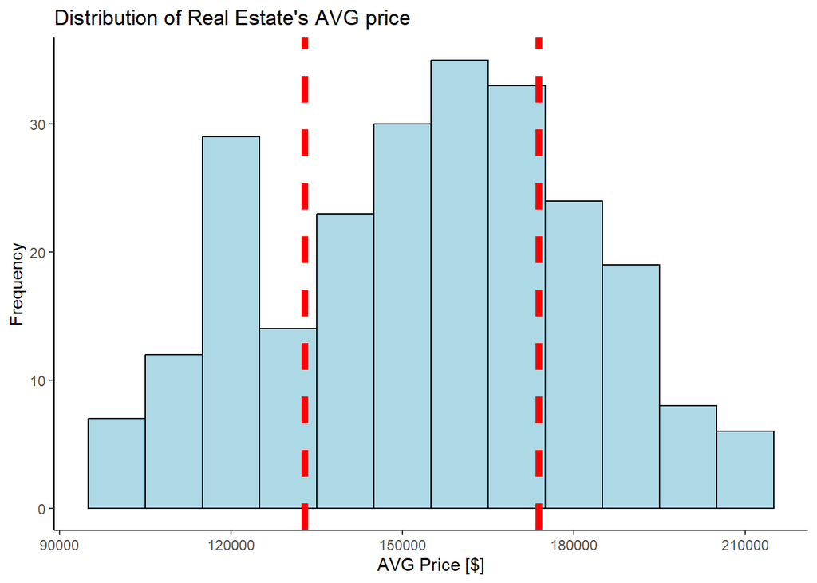

```r
#Histogram x AVG_Price
library(ggplot2)
ggplot(data)+
  geom_histogram(aes(x= avg_price),binwidth = 10000 ,fill= "lightblue",color= "black")+
  geom_vline(xintercept = 132939, color= "red",lty="dashed", lwd=2)+
  geom_vline(xintercept = 173915, color= "red",lty= "dashed", lwd=2)+
  labs(title = "Distribution of Real Estate's AVG price", x="AVG Price [$]", y="Frequency")+
  theme_classic()
```

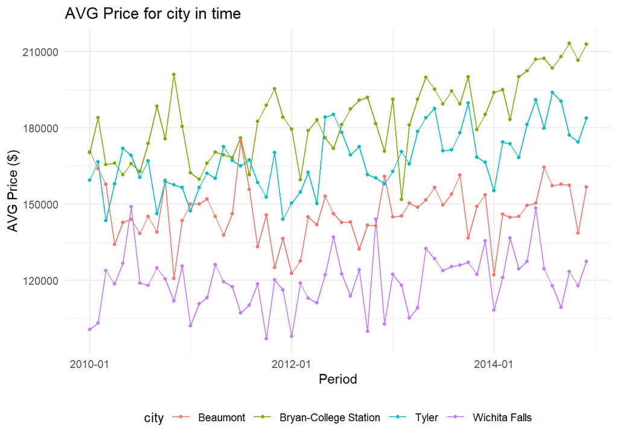

```r
#Line Chart x Avg-Price
data$period <- as.Date(paste(data$year, data$month, "01", sep = "-"))
data$period <- as.Date(paste(data$year, data$month, "01", sep = "-"))
ggplot(data)+geom_line(aes(x = period, y = avg_price, color = city, group = city)) +
  geom_point(aes(x = period, y = avg_price, color = city, group = city),size = 1) +
  labs(title = "AVG Price for city in time",
       x = "Period",
       y = "AVG Price ($)") +
  scale_x_date(date_labels = "%Y-%m")+theme_minimal()+
  theme(legend.position = "bottom")
```

- **Range** : I prezzi medi oscillano tra 97.000 $ e i 213.000 $.
- **Quartili** : il 1° Quartile ( 132.939 $) e il 3° quartile (173.915 $) racchiudono il 50% centrale delle osservazioni.
- **Mediana** : Pari a 156.588 $ ) è molto vicina alla Media ( 154.320 $ ) , suggerendo una distribuzione abbastanza simmetrica.
- **Concentrazione** : La maggior parte degli immobili ha un prezzo medio di vendita tra 130.000 $ - 175.000 $ , con alcuni valori estremi ( 97.000$ - 21000 $ ).
- **Trend Temporale** : dal 2010 al 2011, Il prezzo medio mantiene un andamento costante per tutte le città , mentre dal 2012 si denota una tendenza alla crescita, sopratutto per città come Bryan-Collage Station.

#### - Ads efficiency:

```r
data_efficiency_sort<- data[order(data$efficency),]
kable(
  head(data_efficiency_sort[, c("city", "year", "month", "sales", "volume", "listings", "avg_price", "efficency")]),
  caption = "Ads efficency sorted - dataset Extract"
)
```

Ads efficency sorted - dataset Extract

|  | city | year | month | sales | volume | listings | avg_price | efficency |
| --- | --- | --- | --- | --- | --- | --- | --- | --- |
| 1 | Beaumont | 2010 | 1 | 83 | 14.162 | 1533 | 170626.5 | 0.05 |
| 131 | Tyler | 2010 | 11 | 155 | 24.411 | 3042 | 157490.3 | 0.05 |
| 133 | Tyler | 2011 | 1 | 143 | 21.050 | 2852 | 147202.8 | 0.05 |
| 13 | Beaumont | 2011 | 1 | 108 | 16.200 | 1677 | 150000.0 | 0.06 |
| 14 | Beaumont | 2011 | 2 | 108 | 16.187 | 1691 | 149879.6 | 0.06 |
| 73 | Bryan-College Station | 2011 | 1 | 94 | 15.242 | 1480 | 162148.9 | 0.06 |

```r
#Summary Table "AVG Price"
tabella_summary <- data.frame(
  Statistic = names(summary(data$efficency)),
  Value = as.numeric(summary(data$efficency))
)
kable(tabella_summary, caption = "Descriptive statistics of ADS efficency")
```

Descriptive statistics of ADS efficency

| Statistic | Value |
| --- | --- |
| Min. | 0.0500000 |
| 1st Qu. | 0.0900000 |
| Median | 0.1100000 |
| Mean | 0.1184167 |
| 3rd Qu. | 0.1325000 |
| Max. | 0.3900000 |

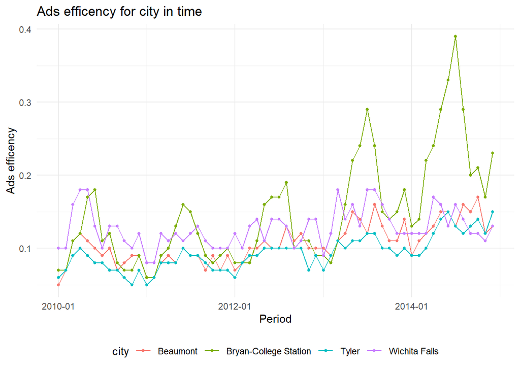

```r
#Line Chart x Avg-Price
ggplot(data)+geom_line(aes(x = period, y = efficency, color = city, group = city))+
  geom_point(aes(x = period, y = efficency, color = city, group = city),size = 1) +
  labs(title = "Ads efficency for city in time",
       x = "Period",
       y = "Ads efficency") +
  scale_x_date(date_labels = "%Y-%m")+theme_minimal()+
  theme(legend.position = "bottom")
```

#### Commento Finale :

- **AVG Price** : I prezzi medi degli immobili si attesta intorno ai 150-170k $ con un distribuzione abbastanza simmetrica/ equilibrata
- **Ads Efficency** : il tasso di conversione pubblicità / vendita degli immobili si concentra sul 10 % con pochi casi che innalzano la media. Dal 2012 mostra un trend crescente nel tempo, suggerendo un miglioramento delle capacità di convertire gli annunci di vendite.

### 7. ANALISI CONDIZIONATA

*Usa il pacchetto `dplyr` o il linguaggio base di R per effettuare analisi statistiche condizionate per città, anno e mese. Genera dei **summary** (media, deviazione standard) e rappresenta graficamente i risultati.*

Inizialmente generiamo dei summary (media e deviazione standard) per effettuare analisi statistiche condizionate per città , anno, mese.

```r
library(dplyr)
#Mean & standard deviation for City & Year/Month
summary_city_year<- data %>%
  group_by(city,year) %>%
  summarise(
    mean_sales = mean(sales, na.rm= TRUE),
    sd_sales = sd(sales, na.rm = TRUE),
    mean_volume = mean(volume, na.rm = TRUE),
    sd_volume = sd(volume, na.rm= TRUE),
    mean_listings = mean(listings, na.rm= TRUE),
    sd_listings= sd(listings, na.rm = TRUE),
    mean_avg_price = mean(avg_price, na.rm = TRUE),
    sd_avg_price = sd(avg_price, na.rm = TRUE),
    mean_efficency = mean(efficency, na.rm = TRUE ),
    sd_efficency = sd(efficency, na.rm = TRUE),
    .groups= "drop"
  )

kable(head(summary_city_year), caption = "Average and Standard Deviation per city and year")
```

Average and Standard Deviation per city and year

| city | year | mean_sales | sd_sales | mean_volume | sd_volume | mean_listings | sd_listings | mean_avg_price | sd_avg_price | mean_efficency | sd_efficency |
| --- | --- | --- | --- | --- | --- | --- | --- | --- | --- | --- | --- |
| Beaumont | 2010 | 156.1667 | 36.92457 | 22.65383 | 4.954348 | 1731.083 | 101.90768 | 146582.5 | 13960.173 | 0.0900000 | 0.0200000 |
| Beaumont | 2011 | 144.0000 | 22.65552 | 21.09525 | 4.300522 | 1747.917 | 74.67439 | 145921.9 | 12655.337 | 0.0808333 | 0.0131137 |
| Beaumont | 2012 | 171.9167 | 28.38840 | 24.46767 | 4.921853 | 1691.333 | 54.55662 | 141475.9 | 10345.771 | 0.1016667 | 0.0158592 |
| Beaumont | 2013 | 201.1667 | 37.73070 | 30.30917 | 6.436956 | 1639.583 | 54.91888 | 150079.0 | 6245.121 | 0.1233333 | 0.0210339 |
| Beaumont | 2014 | 213.6667 | 36.48993 | 32.13208 | 7.049593 | 1586.667 | 57.37331 | 149142.7 | 11234.169 | 0.1341667 | 0.0227470 |
| Bryan-College Station | 2010 | 167.5833 | 70.75368 | 28.73117 | 10.817885 | 1562.417 | 165.15748 | 174601.8 | 11964.068 | 0.1050000 | 0.0382575 |

Ora posso utilizzare questo summarise per le seguenti variabili : `sales`, `volume`, `avg_price`, `listings`, `efficency` per costruire dei grafici per visualizzare analisi statistiche condizionate per città , anno , mese.

#### Visualizzazione Grafica

- **Variables for Years / City**

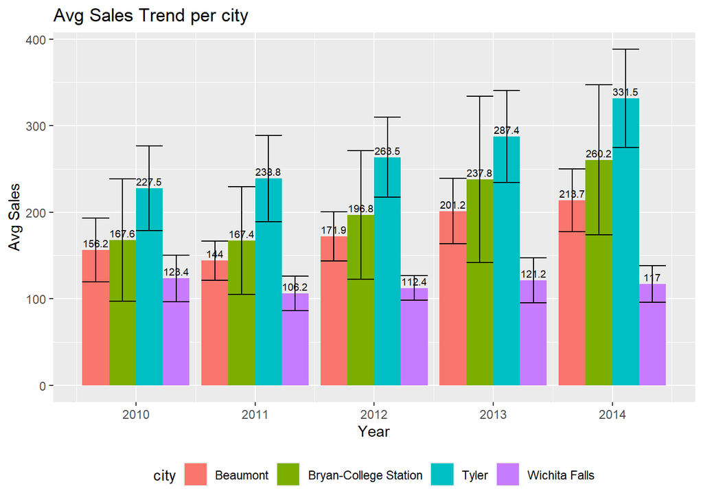

```r
#Graphics per Year

library(scales)
library(ggplot2)

#Barplot x Sales
ggplot(summary_city_year, aes(x= year, y= mean_sales, fill=city))+
  geom_bar(stat= "identity", position= "dodge")+
  geom_errorbar(aes(ymin=mean_sales-sd_sales, ymax = mean_sales+sd_sales), position = position_dodge(width = 0.9))+geom_text(aes(label = round(mean_sales, 1)),position = position_dodge(width = 0.9), size=2.5, vjust= -0.4, hjust= 0.5) +
  labs(title= "Avg Sales Trend per city", x= "Year", y= "Avg Sales")+theme_gray()+
  theme(legend.position = "bottom")
```

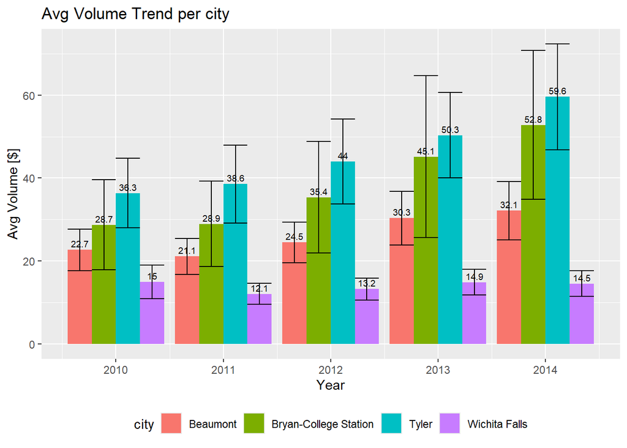

```r
#Barplot x Volume
ggplot(summary_city_year, aes(x= year, y= mean_volume, fill=city))+
  geom_bar(stat= "identity", position="dodge")+
  geom_errorbar(aes(ymin=mean_volume-sd_volume, ymax = mean_volume+sd_volume), position = position_dodge(width = 0.9))+
  geom_text(aes(label = round(mean_volume, 1)),position = position_dodge(width = 0.9), size=2.5, vjust= -0.4, hjust= 0.5) +
  labs(title= "Avg Volume Trend per city", x= "Year", y= "Avg Volume [$]")+theme_gray()+theme(legend.position = "bottom")
```

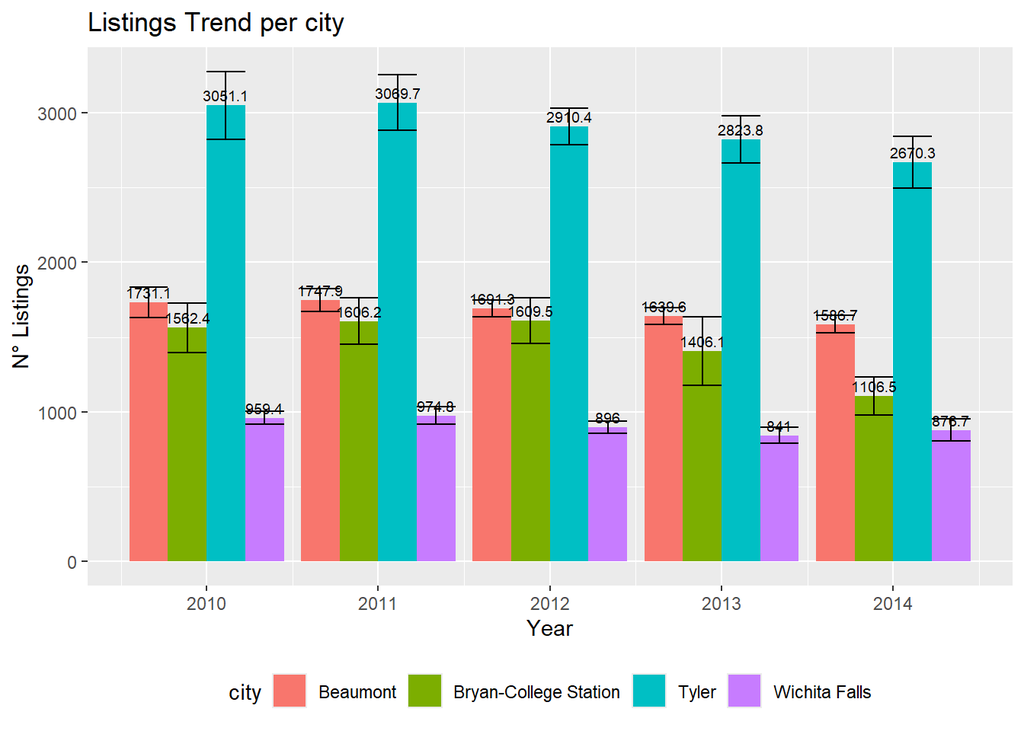

```r
#Barplot x Listings
ggplot(summary_city_year, aes(x= year, y= mean_listings, fill=city))+
  geom_bar(stat= "identity", position="dodge")+
  geom_errorbar(aes(ymin=mean_listings- sd_listings, ymax = mean_listings+sd_listings), position = position_dodge(width = 0.9))+geom_text(aes(label = round(mean_listings, 1)),position = position_dodge(width = 0.9), size=2.5, vjust= -0.4, hjust= 0.5)+
  labs(title= "Listings Trend per city", x= "Year", y= "N° Listings")+theme_grey()+theme_gray()+theme(legend.position = "bottom")
```

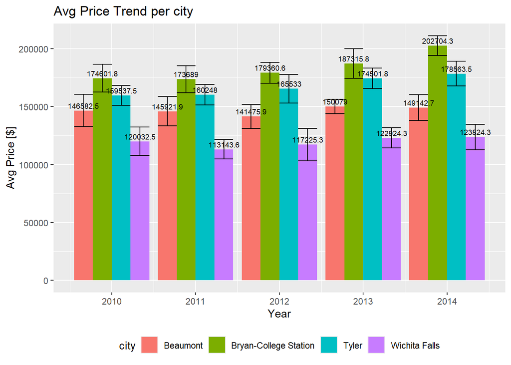

```r
#Barplot x AVG Price
ggplot(summary_city_year, aes(x= year, y= mean_avg_price, fill=city))+
  geom_bar(stat= "identity", position="dodge")+
  geom_errorbar(aes(ymin=mean_avg_price- sd_avg_price, ymax = mean_avg_price+sd_avg_price), position = position_dodge(width = 0.9))+ geom_text(aes(label = round(mean_avg_price, 1)),position = position_dodge(width = 0.9), size=2.5, vjust= -0.4, hjust= 0.5)+ labs(title= "Avg Price Trend per city", x= "Year", y= "Avg Price [$]")+theme_gray()+theme_gray()+theme(legend.position = "bottom")
```

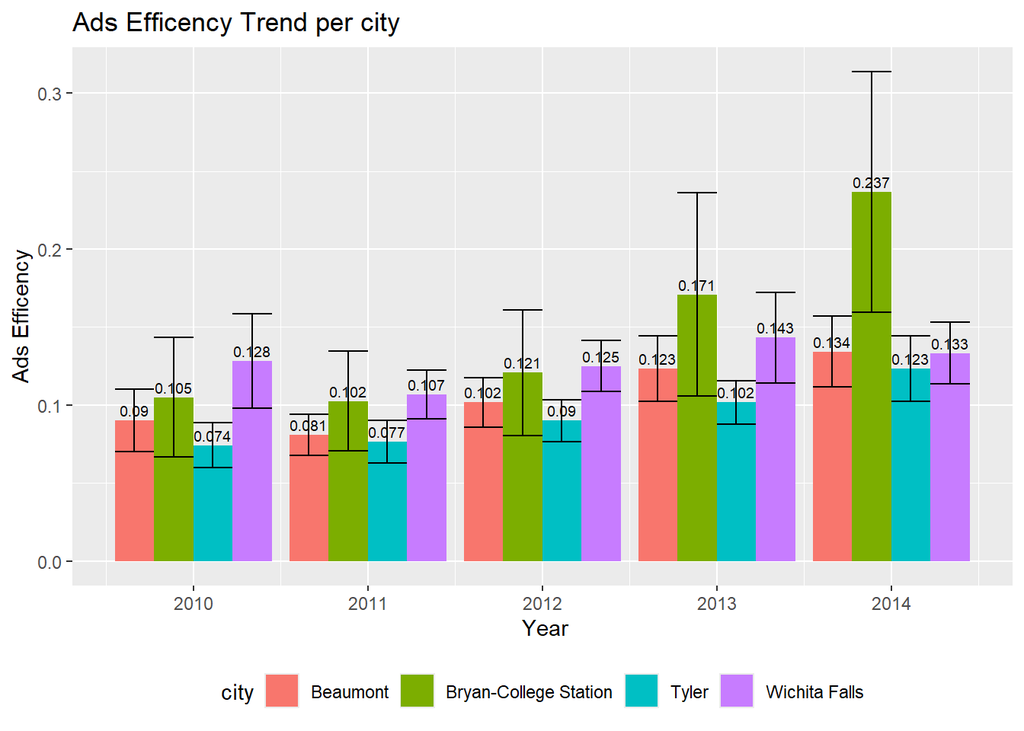

```r
#Barplot x Ads Efficency
ggplot(summary_city_year, aes(x= year, y= mean_efficency, fill=city))+
  geom_bar(stat= "identity", position= "dodge")+
  geom_errorbar(aes(ymin=mean_efficency- sd_efficency, ymax = mean_efficency+sd_efficency), position = position_dodge(width = 0.9))+ geom_text(aes(label = round(mean_efficency, 3)),position = position_dodge(width = 0.9), size=2.5, vjust= -0.4, hjust= 0.5)+ labs(title= "Ads Efficency Trend per city", x= " Year", y= "Ads Efficency")+theme_grey()+theme_gray()+theme(legend.position = "bottom")
```

- **Variables for Months / City**

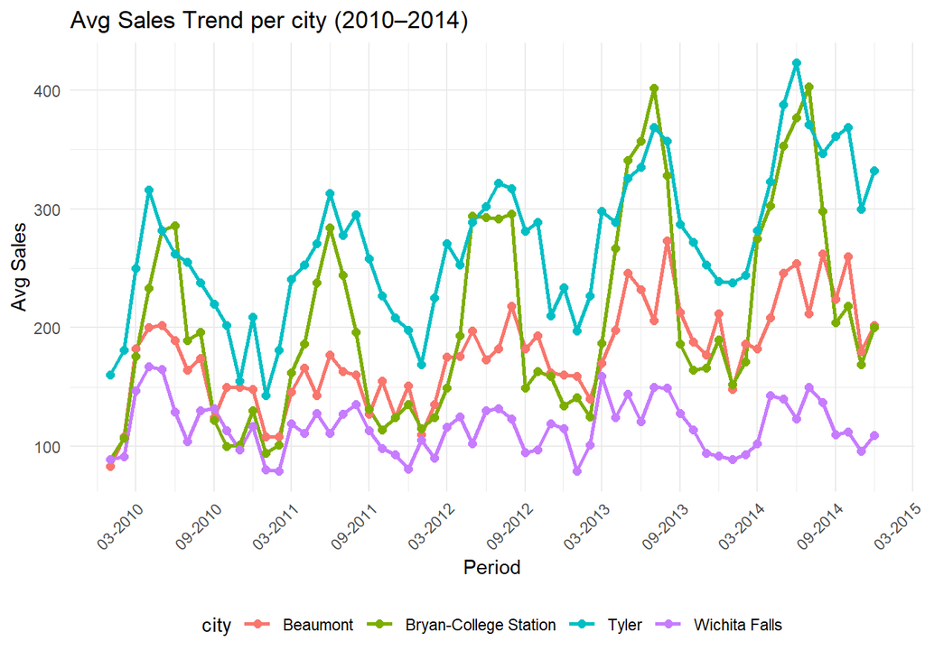

```r
library(dplyr)
#Add Var "Period" : Month +Year
summary_city_month <- data %>%
  group_by(city,year, month) %>%
  summarise(
    mean_sales = mean(sales, na.rm= TRUE),
    sd_sales = sd(sales, na.rm = TRUE),
    mean_volume = mean(volume, na.rm = TRUE),
    sd_volume = sd(volume, na.rm= TRUE),
    mean_listings = mean(listings, na.rm= TRUE),
    sd_listings= sd(listings, na.rm = TRUE),
    mean_avg_price = mean(avg_price, na.rm = TRUE),
    sd_avg_price = sd(avg_price, na.rm = TRUE),
    mean_efficency = mean(efficency, na.rm = TRUE ),
    sd_efficency = sd(efficency, na.rm = TRUE),
    .groups = "drop"
  )%>%
  mutate(period = as.Date(paste(year, month, "01", sep = "-")))

#Barplot x Sales
ggplot(summary_city_month, aes(x = period, y = mean_sales, color = city, group = city)) +
  geom_line(size = 1) +
  geom_point(size = 2) +
  geom_errorbar(aes(ymin = mean_sales - sd_sales, ymax = mean_sales + sd_sales), width = 10) +
  scale_x_date(date_labels = "%m-%Y", date_breaks = "6 months") +
  labs(title = "Avg Sales Trend per city (2010–2014)",
       x = "Period", y = "Avg Sales") +
  theme_minimal() +
  theme(axis.text.x = element_text(angle = 45, hjust = 1),
        legend.position = "bottom")
```

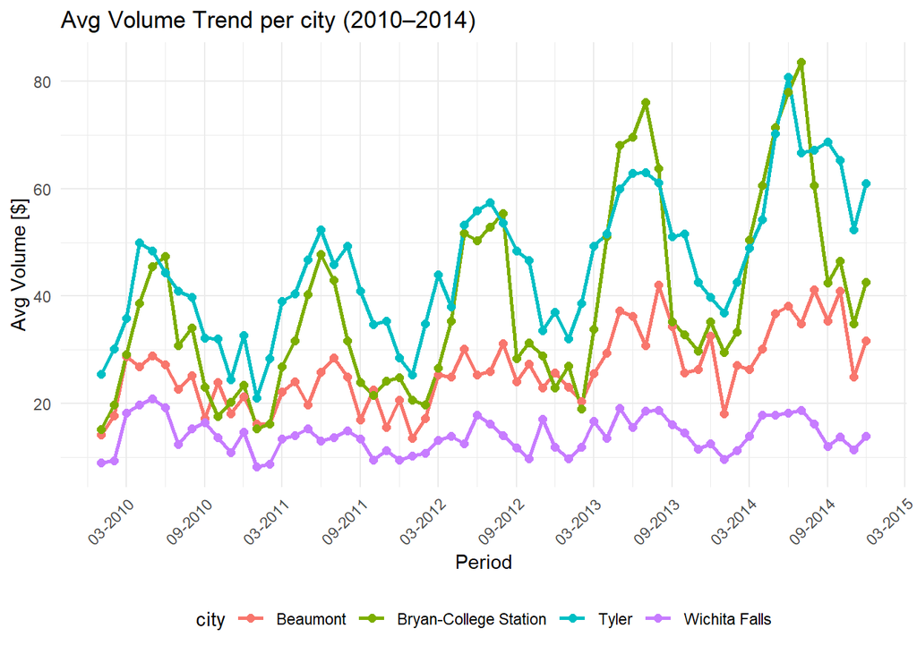

```r
#Barplot x Volume
ggplot(summary_city_month, aes(x = period, y = mean_volume, color = city, group = city)) +
  geom_line(size = 1) +
  geom_point(size = 2) +
  geom_errorbar(aes(ymin = mean_volume - sd_volume, ymax = mean_volume + sd_volume), width = 10) +
  scale_x_date(date_labels = "%m-%Y", date_breaks = "6 months") +
  labs(title = "Avg Volume Trend per city (2010–2014)",
       x = "Period", y = "Avg Volume [$]") +
  theme_minimal() +
  theme(axis.text.x = element_text(angle = 45, hjust = 1),
        legend.position = "bottom")
```

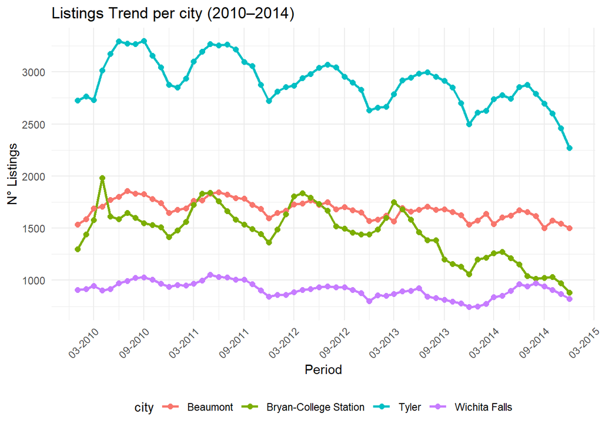

```r
#Barplot x Listings
ggplot(summary_city_month, aes(x = period, y = mean_listings, color = city, group = city)) +
  geom_line(size = 1) +
  geom_point(size = 2) +
  geom_errorbar(aes(ymin = mean_listings - sd_listings, ymax = mean_listings + sd_listings), width = 10) +
  scale_x_date(date_labels = "%m-%Y", date_breaks = "6 months") +
  labs(title = "Listings Trend per city (2010–2014)",
       x = "Period", y = "N° Listings") +
  theme_minimal() +
  theme(axis.text.x = element_text(angle = 45, hjust = 1),
        legend.position = "bottom")
```

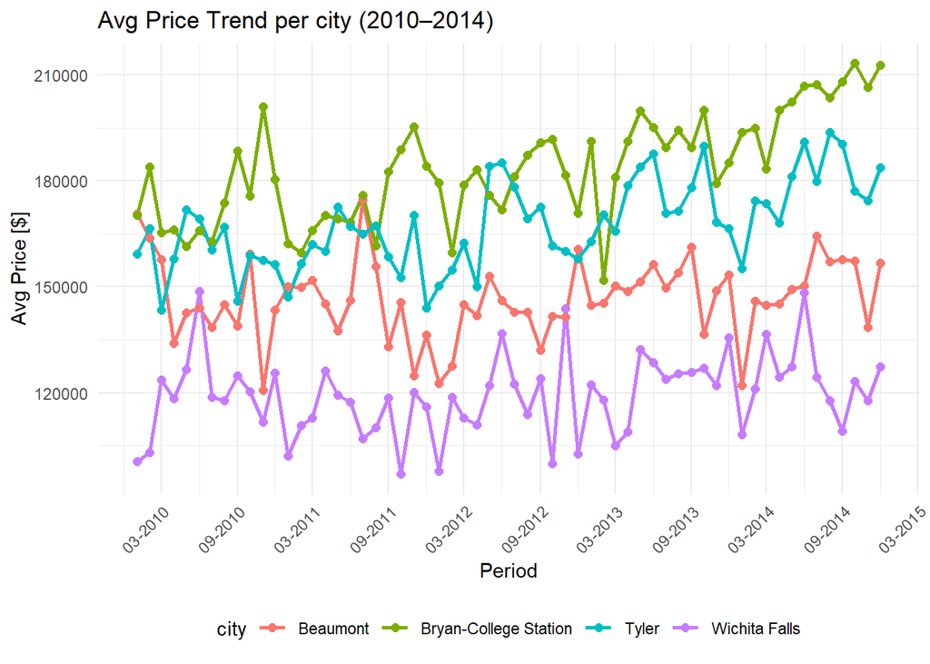

```r
#Barplot x AVG Price
ggplot(summary_city_month, aes(x = period, y = mean_avg_price, color = city, group = city)) +
  geom_line(size = 1) +
  geom_point(size = 2) +
  geom_errorbar(aes(ymin = mean_avg_price - sd_avg_price, ymax = mean_avg_price + sd_avg_price), width = 10) +
  scale_x_date(date_labels = "%m-%Y", date_breaks = "6 months") +
  labs(title = "Avg Price Trend per city (2010–2014)",
       x = "Period", y = "Avg Price [$]") +
  theme_minimal() +
  theme(axis.text.x = element_text(angle = 45, hjust = 1),
        legend.position = "bottom")
```

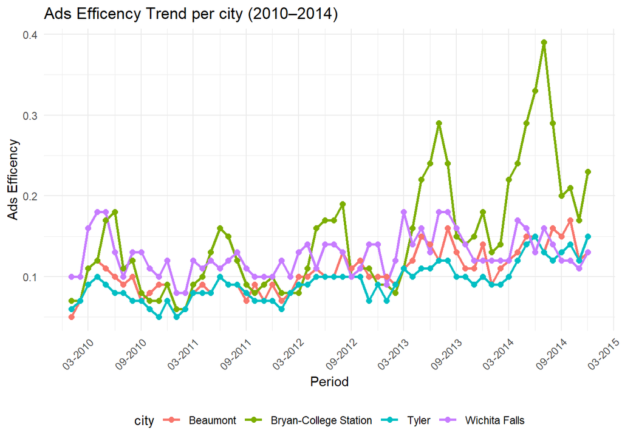

```r
#Barplot x Ads Efficency
ggplot(summary_city_month, aes(x = period, y = mean_efficency, color = city, group = city)) +
  geom_line(size = 1) +
  geom_point(size = 2) +
  geom_errorbar(aes(ymin = mean_efficency - sd_efficency, ymax = mean_efficency + sd_efficency), width = 10) +
  scale_x_date(date_labels = "%m-%Y", date_breaks = "6 months") +
  labs(title = "Ads Efficency Trend per city (2010–2014)",
       x = "Period", y = "Ads Efficency") +
  theme_minimal() +
  theme(axis.text.x = element_text(angle = 45, hjust = 1),
        legend.position = "bottom")
```